# Hybrid Breakdown

Heath Blackmon

April 13, 2016

When can we say anything about the cause of hybrid breakdown using a line cross analysis approach? What data should we collect to be able to identify the cause of the breakdown? A friend and I were discussing how hard it can be to intuitevely have a good feel for the expected genetic architecture even when the pattern is quite simple. In this instance we were discussing a paper (Edmands and Deimler 2004 *Local adaptation, intrinsic coadaptation and the effects of environmental stress on interpopulation hybrids in the copepod Tigriopus californicus* . This paper reported that P1 and P2 are both fit but F1 crosses have reduced fitness and F2 crosses are even less fit. The paper was looking for local adaptation - so a pattern where each of these cohorts exhibits higher fitness under conditions that “most” of its genome was selected for. Akin to the idea of Rundle and Whitlock 2001 - Evolution paper (Something that I hope to add to my LCA software soon). But for simplicity here I am going to assume we don’t have local adaptation and just think about intrinsic genetic incompatability. Since the paper didn’t have any published data that I could crunch, I decided to just make some up that would fit the pattern described.

We can use the R package SAGA to do the analysis and it will let us play around with the assumed species characteristics quite easily. For instance, is it XY or ZW or ESD? Do we really have P1, P2, F1, and F2 or might we have P1, P2, rF1, and rF2.

## First we simulate some data

The standard dataset will be dataset one with P1, P2, F1, F2:

| id | fitness | se.fit |
| --- | --- | --- |
| 3 | 10 | 0.2 |
| 6 | 10 | 0.2 |
| 9 | 9 | 0.2 |
| 15 | 8 | 0.2 |

Our alternate will be dataset two with P1, P2, rF1, rF2:

| id | fitness | se.fit |
| --- | --- | --- |
| 3 | 10 | 0.2 |
| 6 | 10 | 0.2 |
| 12 | 9 | 0.2 |
| 24 | 8 | 0.2 |

## Analyze data

We have a total of 6 analyses we would like to do:

1. XY sex determination
   - cohorts have equal sex ratio
   - cohorts include F1 and F2
2. ESD sex determination
   - cohorts have equal sex ratio
   - cohorts include F1 and F2
3. XY sex determination
   - cohorts have equal sex ratio
   - cohorts include rF1 and rF2
4. ESD sex determination
   - cohorts have equal sex ratio
   - cohorts include rF1 and rF2
5. XY sex determination cohorts
   - have unknown sex ratio
   - cohorts include F1 and F2
6. ESD sex determination cohorts are unknown sex ratio
   - have unknown sex ratio
   - cohorts include F1 and F2

Briefly, the idea of ESD in the saga framework really just means that their is no sex chromosome linked pattern of inheritance present in the genome (though we do have maternal effects and cytotype effects).

Here is the code to run these six analyses

```
res1 <- SAGA::AnalyzeCrossesMM(data1, Cmatrix="XY", even.sex = T)
res2 <- SAGA::AnalyzeCrossesMM(data1, Cmatrix="esd", even.sex = T)
res3 <- SAGA::AnalyzeCrossesMM(data2, Cmatrix="XY", even.sex = T)
res4 <- SAGA::AnalyzeCrossesMM(data2, Cmatrix="esd", even.sex = T)
res5 <- SAGA::AnalyzeCrossesMM(data1, Cmatrix="XY", even.sex = F)
res6 <- SAGA::AnalyzeCrossesMM(data1, Cmatrix="esd", even.sex = F)
```

First thing we might want to do is see if very simplistic datasets like this even have a signal that supports one model more than another. As an example the plot below shows the model weight across the 129 models that can be examined under scenerio 1.

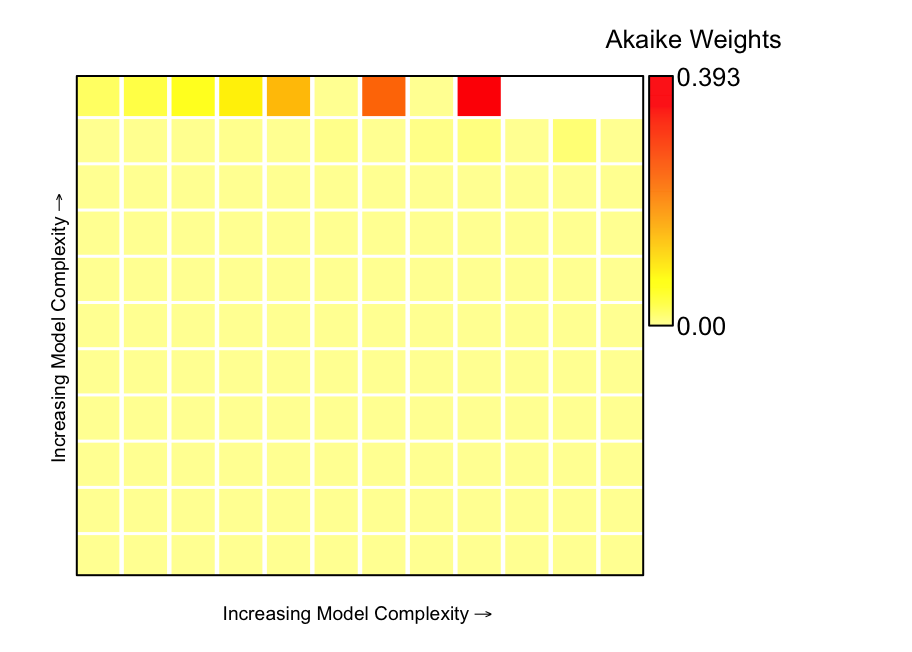

So now lets look at what our data would allow us to infer under each scenario:

1. XY sex determination - 129 models evaluated
   - cohorts have equal sex ratio
   - cohorts include F1 and F2

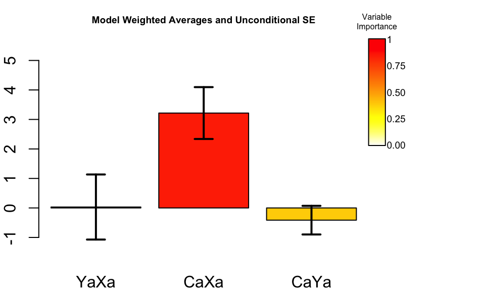

2. ESD sex determination - 28 models evaluated
   - cohorts have equal sex ratio
   - cohorts include F1 and F2
3. XY sex determination - 159 models evaluated
   - cohorts have equal sex ratio
   - cohorts include rF1 and rF2

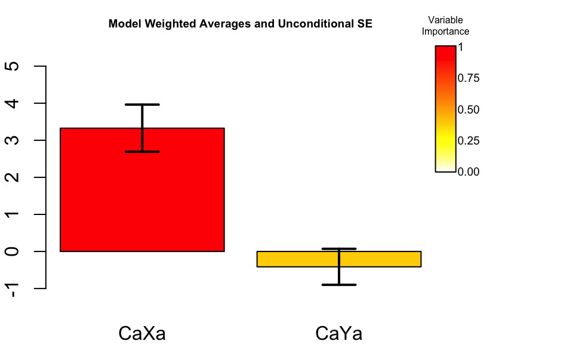

4. ESD sex determination - 35 models evaluated
   - cohorts have equal sex ratio
   - cohorts include rF1 and rF2

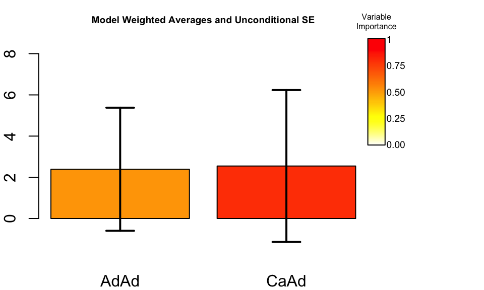

5. XY sex determination cohorts - 28 models evaluated
   - have unknown sex ratio
   - cohorts include F1 and F2
6. ESD sex determination cohorts are unknown sex ratio- 28 models evaluated
   - have unknown sex ratio
   - cohorts include F1 and F2

# Conclusions

The final problem that this little exploration illustrates is the dangers of evaluating a tiny set of models in an information theory framework. I’ve done some simulations previously and it seems that as you attempt to use these approaches on an ever smaller set of models you start putting too much support on the best of the remaining models. Their isn’t an absolute measure of model fit but this might be a nice extension is to report some general measure of % variance explained.